# Lab-8

Zeren Li

10/24/2019

## Roadmap

- Dummy variable & Categotical variable
- Interaction effect
- Margin Effect

### Teaching Rating Dataset

This is a dataaset on course evaluations, course characteristics, and professor characteristics for 463 courses for the academic years 2000–2002 at the University of Texas at Austin.

```r
data(data = "TeachingRatings", package = "AER")

tr1 <- TeachingRatings %>%
  mutate( female = if_else(gender == "female",1,0),
          male = if_else(gender == "male",1,0) ) %>%
  mutate_at(.vars = c("gender", "minority", "tenure", "female", "male"), .funs = function(x){as.factor(x)})
```

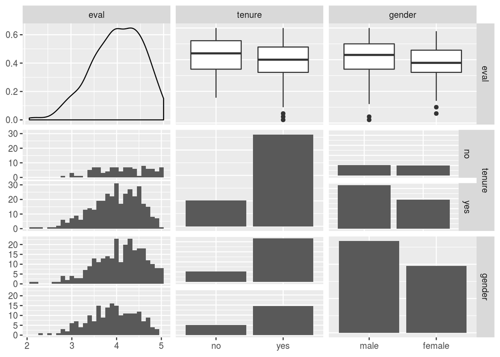

```r
tr1 %>%
  dplyr::select(eval, tenure, gender) %>%
  as.data.frame() %>%
  ggpairs()
```

```r
stargazer::stargazer(tr1, header = F)
```

$$eval = \beta_{0} + \beta_{1}beauty + e$$

```r
m1 <- lm(eval ~ beauty  , tr1 )

summary(m1)
```

```
##
## Call:
## lm(formula = eval ~ beauty, data = tr1)
##
## Residuals:
##      Min       1Q   Median       3Q      Max
## -1.80015 -0.36304  0.07254  0.40207  1.10373
##
## Coefficients:
##             Estimate Std. Error t value Pr(>|t|)
## (Intercept)  3.99827    0.02535 157.727  < 2e-16 ***
## beauty       0.13300    0.03218   4.133 4.25e-05 ***
## ---
## Signif. codes:  0 '***' 0.001 '**' 0.01 '*' 0.05 '.' 0.1 ' ' 1
##
## Residual standard error: 0.5455 on 461 degrees of freedom
## Multiple R-squared:  0.03574,    Adjusted R-squared:  0.03364
## F-statistic: 17.08 on 1 and 461 DF,  p-value: 4.247e-05
```

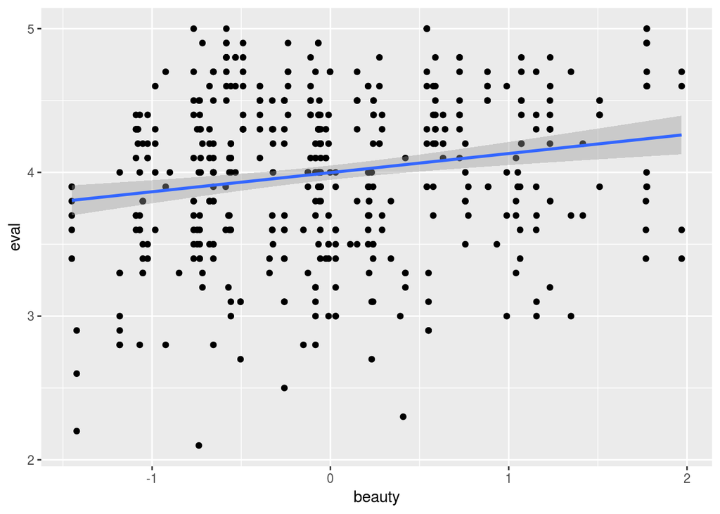

```r
y_hat <- predict(m1)

ggplot(tr1, aes(x = beauty, y = eval)) +
  geom_point() +
  geom_smooth(method = "lm" )
```

$$eval = \beta_{0} + \beta_{1}beauty + \delta gender + e$$

We can interpret the coefficients as follows:

$\beta_0$: the intercept, or the predicted outcome when X=0 and W=0.

$\beta_1$: the slope (or main effect) of beauty; for a one unit change in X, the predicted change in Y.

$\delta$: the slope (or main effect) of gender; for a one unit change in W the predicted change in Y.

$$E(eval) =
\begin{cases}
(\beta_{0} + \delta) + \beta_1 beauty., & \text{female}=1 \\
\beta_{0} +\beta_1 beauty., & \text{female} = 0
\end{cases}$$